# Data Types and Violin Plots

December 14, 2022

## Prepare Library

```r
library(ggplot2)

library(tidyverse)
```

## Data Types, Why Care?

- data types in daily life are simple
  - numbers
  - words
  - logical statements
- data types in R are similar
  - categorises data in different classes
  - different in terms of syntax

## Data Types in R

1. Numeric (1, 2.1, 40, 600.8)
2. Integer (1, 2, 3, 4, 5)
3. Logical (TRUE / FALSE)
4. Character (“Christmas”, “b”)
5. Factor (categorical variables)
6. Complex (i + 9)

## Numeric Data

- numbers, written as integers or decimals

```r
#make vector
n <- c(2, 5.3, 9.7, 15.2)
```

## Is Numeric?

Method 1

```r
is.numeric(n)
```

```
## [1] TRUE
```

Method 2

```r
class(n)
```

```
## [1] "numeric"
```

## Mathematical operations

```r
n
```

```
## [1]  2.0  5.3  9.7 15.2
```

```r
n + 9
```

```
## [1] 11.0 14.3 18.7 24.2
```

```r
n- 1.5
```

```
## [1]  0.5  3.8  8.2 13.7
```

```r
n * 8
```

```
## [1]  16.0  42.4  77.6 121.6
```

## Integer

- numbers, without decimals
- R will make a vector with decimals automatically numeric

```r
i <- c(9, 11, 7, 5, 18)
class(i)
```

```
## [1] "numeric"
```

But you can change that:

```r
i <- as.integer(i)
class(i)
```

```
## [1] "integer"
```

## Create Integer Vector Directly

```r
i_direct <- c(9L, 11L, 7L, 5L, 18L)
i_direct
class(i_direct)
```

```
## [1]  9 11  7  5 18
## [1] "integer"
```

- Some functions will automatically generate integer vectors
- sample ()

## Character

- store text in R
  - strings
  - ” ”

```r
ch <- c("Make", "character", "vector")
ch

class(ch)
```

```
## [1] "Make"      "character" "vector"
## [1] "character"
```

## Number Characters

- Also makes numbers into characters

```r
c_n <- c("5", "9", "11", "13")
class(c_n)
```

```
## [1] "character"
```

- No math possible!

```r
mean(c_n)
```

```
## Warning in mean.default(c_n): argument is not numeric or logical: returning NA
```

```
## [1] NA
```

## Commmon Number Character Issue

- warning when you accidentally have a character value in column of numbers
- space before a number
- circumvent with as.numeric
  - gives NA values
- change data set!

## Logical

- TRUE or FALSE
- T or F
- true or false or t or f do not work!

## Logical Example

```r
numbers <- c(13, 8, 21, 37, 5)

#Ask R if elements in vector are greater than 9
nine <- numbers > 9
nine
```

```
## [1]  TRUE FALSE  TRUE  TRUE FALSE
```

```r
#check class
class(nine)
```

```
## [1] "logical"
```

## Create Logical Vector

```r
l <- c(T, T, F, T,F)
l
```

```
## [1]  TRUE  TRUE FALSE  TRUE FALSE
```

```r
#make numeric
l <- as.numeric(l)
l
```

```
## [1] 1 1 0 1 0
```

## Do Math

```r
l <- as.logical(l)
l
```

```
## [1]  TRUE  TRUE FALSE  TRUE FALSE
```

```r
sum(l)
```

```
## [1] 3
```

## Factor

- used for repeating categories
  - categorical variables

## Example Factor

```r
data <- data.frame(ID = c("Jane", "Matt", "Dan", "Karen", "Harold"),
                   age = c(35, 25, 30, 27, 29),
                   sex = c("female", "male", "male", "female", "male"))

## view data structure
str(data)
```

```
## 'data.frame':    5 obs. of  3 variables:
##  $ ID : chr  "Jane" "Matt" "Dan" "Karen" ...
##  $ age: num  35 25 30 27 29
##  $ sex: chr  "female" "male" "male" "female" ...
```

## Change Data Type

- column sex is character vector
  - want as categorical variable with level m/f

```r
data$sex <- as.factor(data$sex)
data$sex
```

```
## [1] female male   male   female male
## Levels: female male
```

```r
# rest of data is unchanged
str(data)
```

```
## 'data.frame':    5 obs. of  3 variables:
##  $ ID : chr  "Jane" "Matt" "Dan" "Karen" ...
##  $ age: num  35 25 30 27 29
##  $ sex: Factor w/ 2 levels "female","male": 1 2 2 1 2
```

## Factor Levels

- R lists levels in alphabetical order

```r
finish <- factor(c("first", "second", "fourth", "second", "first", "third", "fifth"))
finish
```

```
## [1] first  second fourth second first  third  fifth
## Levels: fifth first fourth second third
```

- change level order

```r
finish <- factor(finish, levels = c("first", "second", "third", "fourth", "fifth"))
finish
```

```
## [1] first  second fourth second first  third  fifth
## Levels: first second third fourth fifth
```

## Numbers as Factor

- Useful to check your data!
  - especially when you read from .csv
- Use: class() str()

## Violin Plots

- Box plots
- Also show kernel probability density of data
- Marker for median of data
- Box indicating interquartile range
  - like standard box plot

## Violin Plots Data

```r
str(diamonds)
```

```
## tibble [53,940 × 10] (S3: tbl_df/tbl/data.frame)
##  $ carat  : num [1:53940] 0.23 0.21 0.23 0.29 0.31 0.24 0.24 0.26 0.22 0.23 ...
##  $ cut    : Ord.factor w/ 5 levels "Fair"<"Good"<..: 5 4 2 4 2 3 3 3 1 3 ...
##  $ color  : Ord.factor w/ 7 levels "D"<"E"<"F"<"G"<..: 2 2 2 6 7 7 6 5 2 5 ...
##  $ clarity: Ord.factor w/ 8 levels "I1"<"SI2"<"SI1"<..: 2 3 5 4 2 6 7 3 4 5 ...
##  $ depth  : num [1:53940] 61.5 59.8 56.9 62.4 63.3 62.8 62.3 61.9 65.1 59.4 ...
##  $ table  : num [1:53940] 55 61 65 58 58 57 57 55 61 61 ...
##  $ price  : int [1:53940] 326 326 327 334 335 336 336 337 337 338 ...
##  $ x      : num [1:53940] 3.95 3.89 4.05 4.2 4.34 3.94 3.95 4.07 3.87 4 ...
##  $ y      : num [1:53940] 3.98 3.84 4.07 4.23 4.35 3.96 3.98 4.11 3.78 4.05 ...
##  $ z      : num [1:53940] 2.43 2.31 2.31 2.63 2.75 2.48 2.47 2.53 2.49 2.39 ...
```

## Basic Violin Plot

```r
ggplot(diamonds)+
  geom_violin(aes(x = cut, y = carat))
```

## Basic Violin Plot

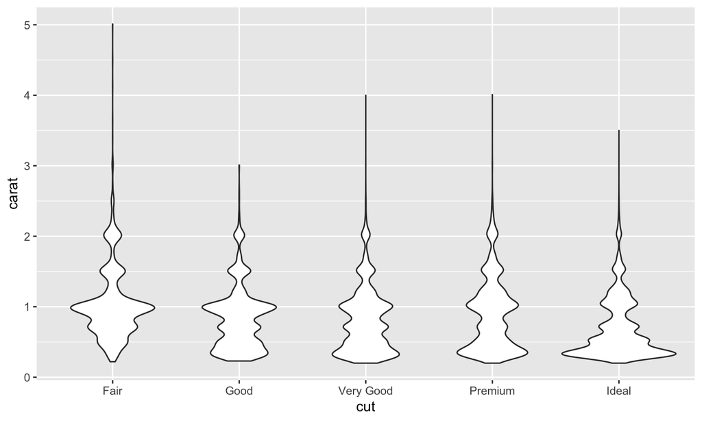

```r
ggplot(diamonds)+
  geom_violin(aes(x = cut, y = carat))
```

## Rotate Violin Plot

```r
gplot(diamonds) +
  geom_violin(aes(x = cut, y = carat)) +
  coord_flip()
```

## Rotate Violin Plot

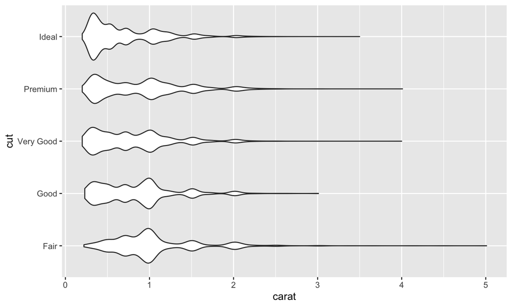

```r
ggplot(diamonds) +
  geom_violin(aes(x = cut, y = carat)) +
  coord_flip()
```

## Add Summary Statistics: Mean

```r
ggplot(diamonds, aes(x = cut, y = carat)) +
  geom_violin() +
  stat_summary(fun = mean, geom = "point", shape = 8, size = 5, colour = "darkblue")
```

## Add Summary Statistics: Mean or Median)

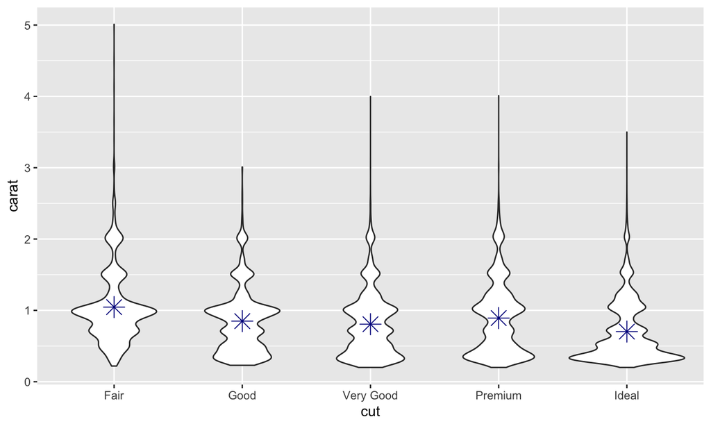

```r
ggplot(diamonds, aes(x = cut, y = carat)) +
  geom_violin() +
  stat_summary(fun = mean, geom = "point", shape = 8, size = 5, colour = "darkblue")
```

## Add Mean and Standard Deviation

- use mean_sdl
  - mean +/- constant x SD
- plot as crossbar or pointrange

```r
stat <- function(x) {
  ave <- mean(x)
  ymin <- ave- sd(x)
  ymax <- ave + sd(x)
  return(c(y = ave, ymin = ymin, ymax = ymax))
}
```

## Add Mean and Standard Deviation

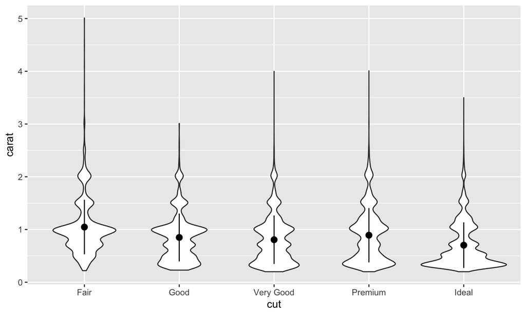

```r
ggplot(diamonds, aes(x = cut, y = carat)) +
  geom_violin() +
  stat_summary(fun.data = stat)
```

## Add Median and Quartile

```r
ggplot(diamonds, aes(x = cut, y = carat)) +
  geom_violin() +
  geom_boxplot(width = 0.1)
```

## Add Median and Quartile

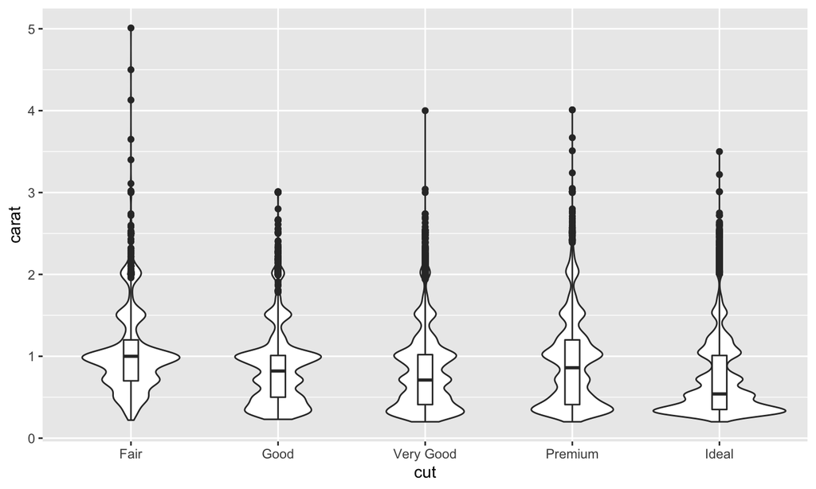

```r
ggplot(diamonds, aes(x = cut, y = carat)) +
  geom_violin() +
  geom_boxplot(width = 0.1)
```

## Change Colour

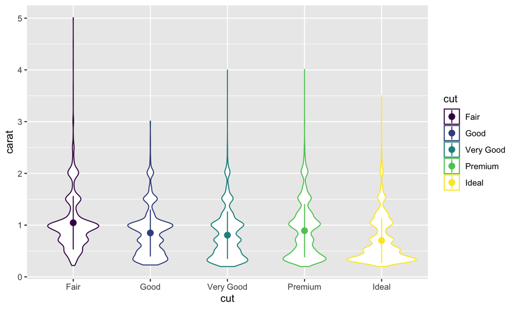

```r
ggplot(diamonds, aes(x = cut, y = carat, colour = cut)) +
  geom_violin() +
  stat_summary(fun.data = stat)
```

## More options

- change fill colour
- change legend potion
  - (theme)
- change order
- multiple groups
- …